# Homework #6: Due 3/9/21 to Canvas by 1 pm

Data Science for Biologists, Spring 2021

Dr. Spielman

## Instructions

For your assignment, you will be honing your `dplyr` and `ggplot2` skills using a previous Tidy Tuesday dataset about coffee. The dataset is described and documented [here](https://github.com/rfordatascience/tidytuesday/blob/master/data/2020/2020-07-07/readme.md). *It really helps to read about the dataset to be able to work with it!!* Use the `hw6_template.R` script in the Homework #6 RStudio Cloud Project to complete this homework. The dataset is read in for you in this script.

### Please read these additional instructions carefully:

- **ALWAYS RUN AND CHECK CODE ONE LINE AT A TIME!!!**
- Unless otherwise stated, your wrangling code to answer a given question **MUST** all be part of the same connected pipeline with `%>%`.
- You will not receive any credit for answers without corresponding code that produces those answers.
- Make sure your code runs WITHOUT an errors before submitting. *A 10% penalty is automatically applied for submissions with bugs that lead to errors.*
  - If there are errors in your code, you should *comment out* the code so that it does not actually run. This is **BETTER** than allowing buggy code to run - it shows me you attempted the code, but understood that it didn’t work properly. If you leave buggy code in the script without commenting it out, there will be deductions.
- Make sure you are commenting out any code that does not specifically contribute to the homework. For example, `View()` should never be in scripts. Similarly, while exploring a dataset with functions like `head()`, `names()`, or `str()` is completely and entirely necessary for completing this assignment, the code you use to do so is not specifically part of the code to create and save plots. Therefore, either run those commands directly in Console, or comment them out in your final script.
- Be careful not to *duplicate* your code. For example, do not write code on one line, and then on the next line write it again and save it to a variable. Only include the second line in the final version of your script!
- **As always, you are encouraged to work together and use the class Slack to help each other out, but you must submit YOUR OWN CODE.**
- **Plotting rules:**
  - All plots must be professionally labeled with clean X and Y axes. You are not required to include a title, subtitle, or caption, but you may include one or more of these labels if you personally want to.
  - All plots you are instructed to save to a PNG file must be clearly legible with an appropriate aspect ratio. This means you may need to change the output plot size using arguments `width` and `height` when calling `ggsave()`. *Make extra sure to LOOK AT YOUR SAVED PLOTS* and tweak the size until it looks clearly professional.
  - You may also need to modify certain theme components to achieve a professional look!

## Questions

1. There is one farm in Guatemala (column `country_of_origin`) which has a `total_cup_points` score less than 70. What is its name (column `farm_name`)? Your code should print a tibble with one column, `farm_name`, and one row with the farm name of interest.

   To answer this question, first use `filter()` to find all coffees (rows) that meet the conditions given (its `country_of_origin` is Guatemala and its `total_cup_points` is below 70). Then, use `select()` to keep only the `farm_name` column. There you go!
2. How many different Bourbon variety coffees (`variety` column) are from Brazil? Your code should yield a single number that answers the question.

   Hint: To answer this question, first use `filter()` to subset the data to coffees (rows) that meet the conditions. Then, as the next step in the same pipeline, use `tally()` or `nrow()` as the final function in your pipeline to count the rows. *See the `dplyr` exercises for more about those functions in this context!*
3. How many distinct combinations of species and country of origin are in this dataset? Your code should yield a single number that answers the question, To do this…
   - First select only the relevant columns (makes it easier to see and do the next steps)
   - Find all distinct rows
   - For fun (and also for your grade), ensure that your results are sorted (arranged!) by the name of the country.

> Hint: There is a specific `dplyr` function we have learned to keep only the *distinct* rows - `distinct()`!

> Hint: Do not worry about any potential NAs in your answers. Let’s consider those as countries/species for now.
4. In the previous question, I told you to find all distinct rows in step 2. The order of these steps actually matters! The goal of this question is for you to really understand why we have to carefully plan our steps in the right order, which also illuminates why it is so important to build up your pipelines *one step at a time.*

   For this question, write code that takes the same steps as the previous question, but in this order:
   - First all distinct rows in the full dataset
   - THEN select only those columns
   - Finally, arrange by country of origin

   After examining the output from that code, in a comment **BELOW** that code (two sentences max!), explain *in your own words* why re-ordering the steps like this does not give the same answer as #3 and why this answer is wrong.

> Hint: To really understand the difference, go LINE! BY! LINE!

> Hint: Here is an analogy. Imagine you are doing laundry. To accomplish this goal, you first wash dirty clothes in the washing machine, then dry them in the dryer, and then put them back in the closet. It would be silly to take these steps in any other order, because *it’s all about the OVERALL PROCESS, not just running individual lines of code, oh, I mean steps*.
5. Use `mutate()` to make a new column in the dataset called `moisture_decimal` which contains the moisture score divided by 100. Your final code should yield a tibble with only TWO columns: `moisture` and `moisture_decimal` *in that order*, and *arranged in **descending** order of moisture*.

> Hint: You will need to use the functions `select()` and `arrange()` as well for this question.

> Hint: For this question, there are many ways you can combine these commands together into the final pipeline. *As a general rule: As long as your code works and achieves the goal, the specific pipeline order doesn’t matter at all.* It’s all about taking the steps in the order that achieves the goal.
6. Arabica is the most commonly grown species of coffee that is grown, but there is another species “Robusta.” Find all *farms* (`farm_name` column) that grow Robusta coffees. Your code should yield a tibble with TWO columns: the `farm_name` and `country_of_origin` for all places growing Robusta coffee, *without any duplicated rows*.

> Hint: Do not worry about any potential NAs in your answers. Let’s consider those as countries/species for now.

> Hint 2: Did you notice that *without any duplicated rows* is italicized?
7. Find all the coffees grown in the USA. In this dataset, USA locations are represented as *one of the following* in `country_of_origin`: `"United States"`, `"United States (Hawaii)"` , `"United States (Puerto Rico)"`. Your code should yield a tibble containing all columns from the original dataset, but subsetted to rows *where the `country_of_origin` is one of those USA options.*

> Hint: You cannot use the `==` operator in your `filter()` command, since we are looking for *one of three conditions*, not all at once!. You therefore need to use the `%in%` operator to filter for rows where the `country_of_origin` is `%in%` an array containing those options.
8. An awesome `dplyr` function that we haven’t seen yet is `count()`: This function counts the number of rows for a given variable. For example, the code below counts how many coffees (rows) from each country. **You will want to run this code to clearly examine and engage with the `count()` function and its output!!**

   ```r
   coffee_ratings %>%
     # counts: how many rows are there for each country_of_origin
     count(country_of_origin)
   ```

   ```
   ## # A tibble: 37 x 2
   ##    country_of_origin     n
   ##    <chr>             <int>
   ##  1 Brazil              132
   ##  2 Burundi               2
   ##  3 China                16
   ##  4 Colombia            183
   ##  5 Costa Rica           51
   ##  6 Cote d?Ivoire         1
   ##  7 Ecuador               3
   ##  8 El Salvador          21
   ##  9 Ethiopia             44
   ## 10 Guatemala           181
   ## # … with 27 more rows
   ```

   Use this function to count the number of each coffee species in the dataset. Your code should yield a tibble indicating how many of each species there are. **Make sure that the name of the column showing the number of species is called `total_count`.**

> Hint: You will want to use `dplyr` the function `rename()`.
9. Consider the *demo code* for the previous question: Modify this code (it needs *one* more pipe!!) to answer the question, Which country grows the *most* coffees in the world? Your code should yield a tibble with one row representing the country with the most coffees.

> Hint: The country that appears the most times in the dataset (remember how the demo *counts the number of times each country appears?*) grows the most coffees in the world.

> Hint 2: How do you subset to only that row? It should have the *maximum count value*. In other words, only keep the row whose `n` value is equal to the maximum value for `n`.

> Hint 3: **Do NOT** use the `arrange()` function to find the answer, and do NOT hardcode any values!
10. Use `mutate()` to create a new column in the dataset called `cup_rank` where coffees with < 88 `total_cup_points` have the value “low”, and coffees with >= 88 (aka, otherwise) `total_cup_points` have the value “high”. Then, *count* how many coffees are in each new category. Your code should yield a tibble with just the counts and cup rank categories (two rows and two columns).

> Hint: As part of your `mutate()` code, you will need to use the `ifelse()` function.
11. Choose your three favorite countries in the dataset which have at least 25 rows of data. Then…
    - Create an array of your three countries. Use this array variable as part of your code going forward - do not ever type those country names again!
    - Subset your data to only contain coffees from those countries.
    - Subset your data columns to only keep the columns `country_of_origin`, `number_of_bags`, `acidity`, and `balance` (any order is fine).
    - Create a new column called `acid_balance_ratio` that contains the acidity divided by balance values.
    - Save this tibble to a new variable called `my_coffees`. You do not need to print anything for this question.

> Hint: Need help choosing countries? Why not use `dplyr` to explore the data first and figure out which countries have at least 25 rows of data, and then choose one of those!

> Hint 2: If you do use code to explore the data and help you choose a country (and there are MANY ways to do this!), keep that code in your homework but *commented out* so I can see your exploration, and I’ll give some extra credit if it’s not buggy! *This sort of exploration is one of the main benefits of `dplyr`!*
12. Using your fancy new `my_coffees` dataset, you will make two plots (one for this question, one for the next question) that show the *relationship* between acidity and balance.

    For this question, make a scatterplot to show the relationship between the variables `acidity` and `balance`, where the plot is *faceted by country*, points are colored by country, and each facet should have its own trendline for the given country. Save your plot with `ggsave()` to a file called `"acidity_balance.png"` (do not also submit the png file with your homework though!). You do not need to print the plot, but you can.

    In a comment below your plotting code, provide a brief 1-2 sentence interpretation of this figure - what is the relationship between acidity and balance, and is it different/same across your three countries?
13. Again using your `my_coffees` dataset, visualize the relationship between these variables in a different way: Plot the distribution of `acid_balance_ratio` across your three chosen countries. You can facet or not based on your preference, but all three distributions should have distinct colors and/or fills. Save your plot with `ggsave()` to a file called `"acid_balance_ratio.png"` (do not also submit the png file with your homework though!). You do not need to print the plot, but you can.

    In a comment below your plotting code, provide a brief 1-2 sentence interpretation of this figure, bearing in mind: If the values for this ratio are generally greater than 1, that means the coffees have more acidicity than balance. If the values for this ratio are generally less than 1, that means the coffees have more balance than acidity. If the values for this ratio are roughl equal to 1, the coffees have roughly the same acidity and balance levels.

**Random geoms you might want when making this plot, just in case** (no pressure, or need at all, just sometimes students ask about these):

Are you interested in adding a horizontal line or vertical line?

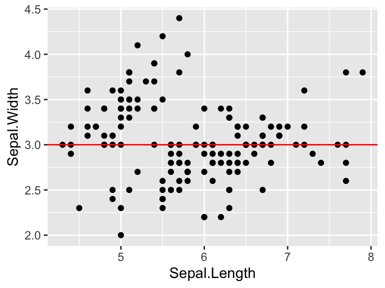

```r
ggplot(iris, aes(x = Sepal.Length, y = Sepal.Width)) +
  geom_point() +
  # makes a horizontal line at y = 3
  geom_hline(yintercept = 3,  color = "red")
```

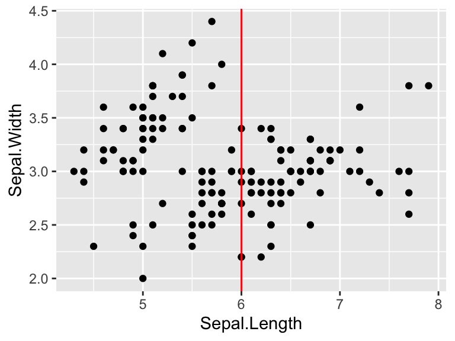

```r
ggplot(iris, aes(x = Sepal.Length, y = Sepal.Width)) +
  geom_point() +
  # makes a vertical line at x = 6
  geom_vline(xintercept = 6, color = "red")
```

Do you remember `stat_summary()` to show mean +/- SE? It’s a really powerful and flexible function, actually.

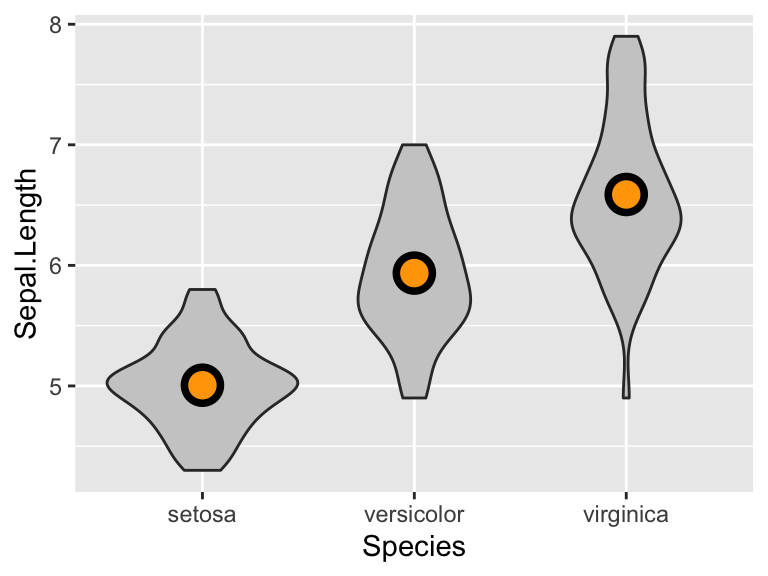

```r
ggplot(iris, aes(x = Species, y = Sepal.Length)) +
  geom_violin(fill = "grey80") +
  #let's have fun!
  stat_summary(geom = "point", # specifies to just make the summary a point
               fun = "mean",   # calculate and show mean (NOT default mean +/- se)
               shape = 21,     # when using this shape, ......
               size = 5,       # size specifies size of the point itself
               stroke = 2,     # stroke specifies size of the point outline
               color = "black",
               fill = "orange")
```

14. Plot the distribution of altitudes where the coffee is grown (use the column `altitude_mean_meters`), specifically considering all coffees grown in Costa Rica and Honduras (plotted as *separate distributions*, not all pooled together). First, create the dataset you need to plot using `dplyr`, save it to a variable, and then use that data to plot the distributions using styling and a geom of your choosing, as long as the distributions are clearly shown! You do NOT need to save this image to a file, but you SHOULD save to a variable and print it.
15. In fact, it is possible to directly pipe datasets into `ggplot()` because `ggplot()`’s first argument is also a dataframe!! The example code below shows this in action **(you must be careful to type `%>%` and `+` in the right place!!!)**

    Use this strategy (ie, like the second example above) to re-make a version of your plot from the previous question. Wrangle the data just as you did, but *pipe it into ggplot2 directly*. In addition, this time use a *different geom* from question 14’s version to show these two distributions. Again, just print the plot - no need to save to a file.

    In a comment below your plotting code, answer in 1-2 sentences: *In your opinion*, which of your two plots better communicates the two distributions of altitudes, and **why?**

#### Examples of piping into `ggplot()`

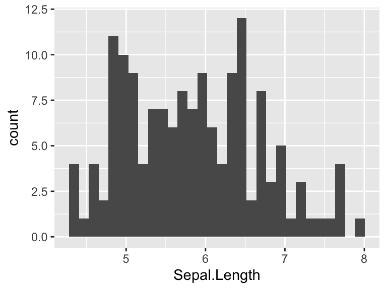

```r
iris %>% # data frame out --->
  # ----> data frame in. We can "SKIP" the first argument since it's being PIPED IN INSTEAD
  ggplot(aes(x = Sepal.Length)) +
    geom_histogram()
```

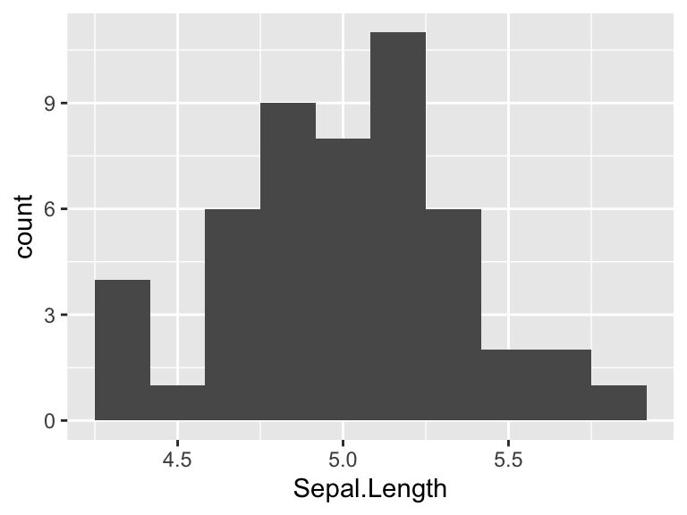

```r
iris %>%
  filter(Species == "setosa") %>% # data frame out --->
  # ----> data frame in
  ggplot(aes(x = Sepal.Length)) +
    geom_histogram(bins = 10)
```

```r
## NO!! This is giving ggplot() iris TWICE!!
## Again, NO!!!
## See? There's an error!!
iris %>%
  ggplot(iris, aes(x = Sepal.Length)) +
    geom_histogram()
```

```
## Error: Mapping should be created with `aes()` or `aes_()`.
```

## Bonus Questions

**BONUS QUESTION Part 1**  
Let’s learn one more geom: [`geom_text()`](https://ggplot2.tidyverse.org/reference/geom_text.html). This geom will place a label at a particular x/y location: It’s just like `geom_point()` but instead of a point, it draws a label instead. The label needs to be specified either as “just a label”, or as an *aesthetic* mapped to the data using `aes(label = COLUMN)`.

Use `geom_text()` to make a plot of the relationship between `balance` and `flavor` (`balance` on Y, `flavor`on X) for all coffee from El Salvador, and set the label aesthetic to be `number_of_bags` (how many bags of coffee the farm produces). Specify both `geom_point()` and `geom_text()` (this plot will NOT look ideal; that’s correct!). When writing your code, directly pipe your wrangling into `ggplot()` and style away as you wish. You should *print* the plot (no need to save to a file) for this question.

**BONUS QUESTION Part 2**  
Now, feel disappointed in how ugly that plot looks, and take this opportunity to learn the basic usage of a new library [`ggrepel`](https://cran.r-project.org/web/packages/ggrepel/vignettes/ggrepel.html) (that is a link to a post!! Go over the post to do this question!!) If you choose to do this bonus, please add the code `library(ggrepel)` to the top of the script in the section where libraries are loaded (it is installed for you in RStudio Cloud). Use `ggrepel` to make a scatterplot of the relationship between `balance` and `flavor` for all coffees from El Salvador. Using either `geom_text_repel()` or `geom_label_repel()` (your choice), label all points based on their *farm name*. You can include any other viz strategies and styles you like here! Again, print the plot, but don’t save it to a file.

**BONUS QUESTION Part 3**

For fun, make the plot in one more way - instead of labeling points based on `number_of_bags`, **color** (or fill if you specify a different type of point) points based on `number_of_bags`. You do not need to include any text geoms, repelled or otherwise. Ensure professional labels all around, including the legend! *To get these bonus points, you MUST use a non-default color scale of your choosing.*